# TS Assignment 5

Yunshuang Jiang

11/3/2020

```r
library(stringr)
library(xts)
library(forecast)
library(fpp)
```

(2 points) Question 1: Load the condmilk.rda dataset and split it into a training dataset (1971/1 – 1979/12) and a test dataset (1980/1 – 1980/12)

```r
# Split the training and test sets
traindat = window(condmilk, start = c(1971,1), end = c(1979,12))
testdat = window(condmilk, start = c(1980,1), end = c(1980,12))
```

(3 points) Question 2: Plot the training dataset. Is Box-Cox transformation necessary for this data?

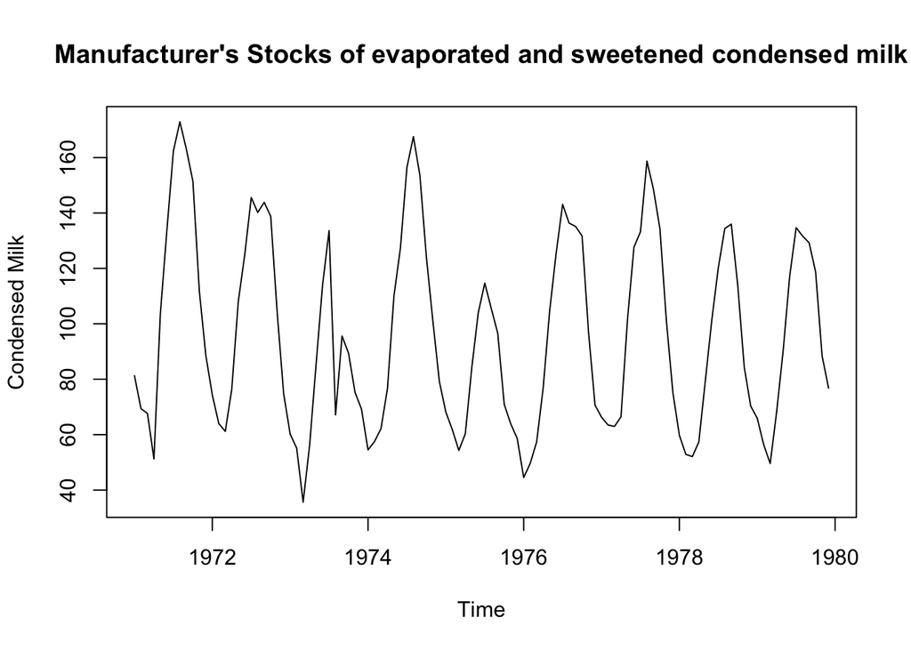

```r
ts.plot(traindat, type = 'l', ylab='Condensed Milk',main="Manufacturer's Stocks of evaporated and sweetened condensed milk")
```

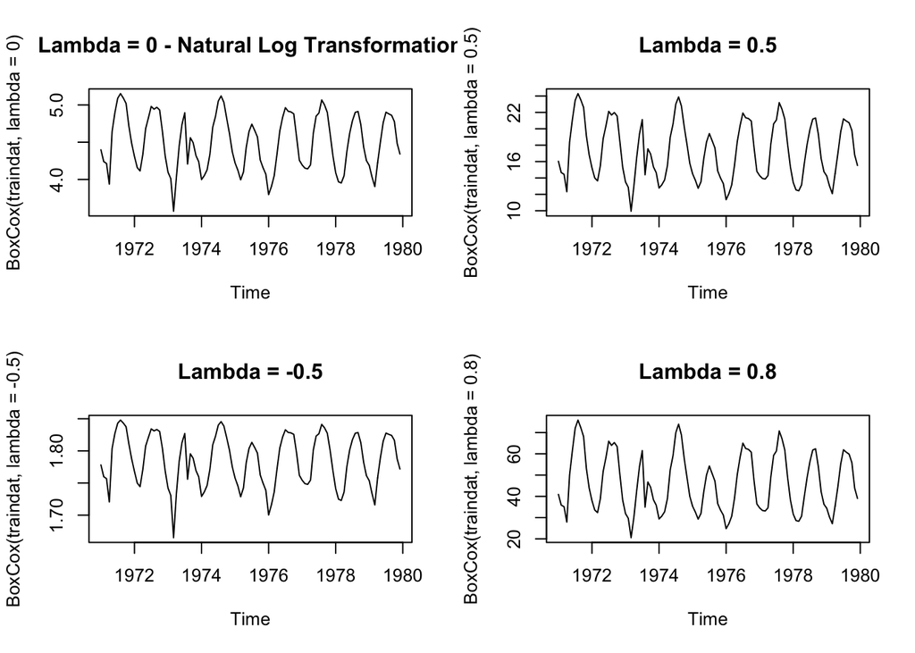

```r
# Try with different lambda
par(mfrow=c(2,2))
plot(BoxCox(traindat, lambda = 0), type = 'l', main = "Lambda = 0 - Natural Log Transformation")
plot(BoxCox(traindat, lambda = 0.5), type = 'l', main = "Lambda = 0.5")
plot(BoxCox(traindat, lambda = -0.5), type = 'l', main = "Lambda = -0.5")
plot(BoxCox(traindat, lambda = 0.8), type = 'l', main = "Lambda = 0.8")
```

```r
BoxCox.lambda(traindat)
```

```
## [1] -0.3944237
```

Automatic selection of Box Cox transformation parameter is -0.39. I plotted the training data with lambda equal to 0.5 and I do not see much difference between the original plot, the plot with other lambdas we tried, and lambda = -0.5. Therefore, box-cox transformation is not necessary to be applied to our training data.

(5 points) Question 3: Is the training dataset stationary? If not, find an appropriate differencing which yields seasonal and trend stationary training dataset. Plot the ACF and PACF to determine if the detrended and deseasonalized time series is stationary.

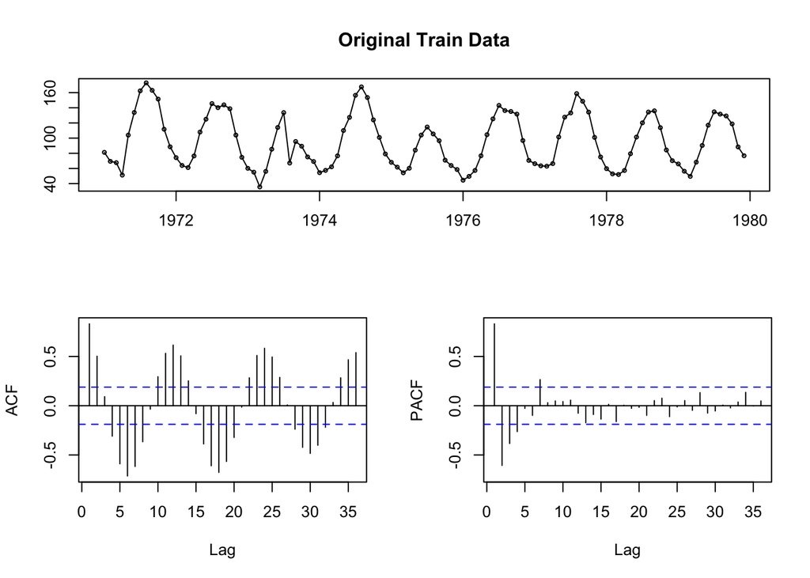

```r
tsdisplay(traindat, main='Original Train Data')
```

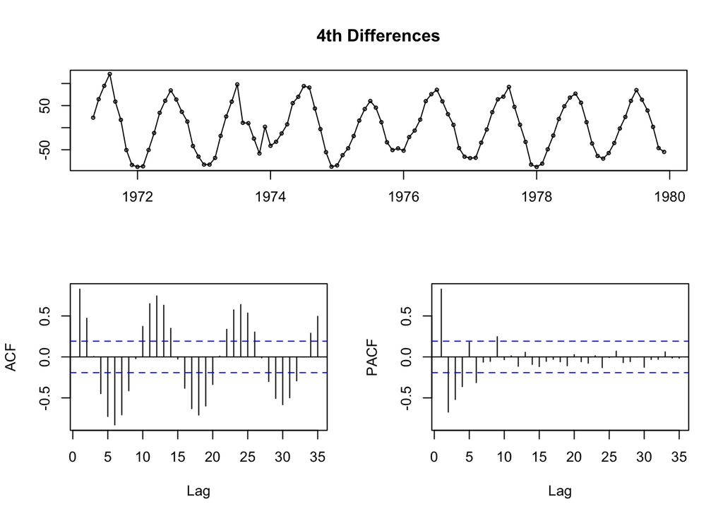

```r
traindatdiff4 <- diff(traindat,4)
tsdisplay(traindatdiff4,main='4th Differences')
```

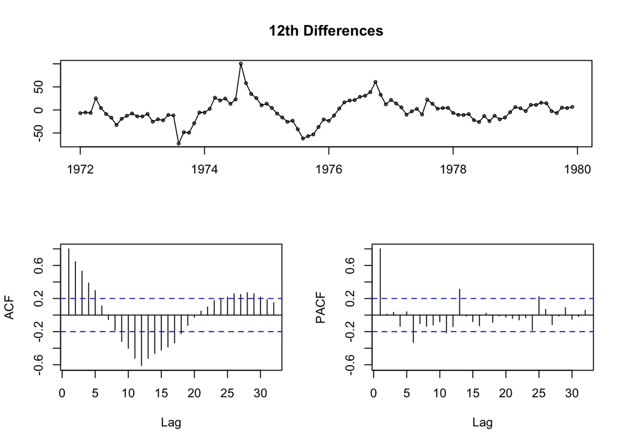

```r
traindatdiff12 <- diff(traindat,12)
tsdisplay(traindatdiff12,main='12th Differences')
```

```r
#kpss test
kpss.test(traindat)
```

```
##
##  KPSS Test for Level Stationarity
##
## data:  traindat
## KPSS Level = 0.042964, Truncation lag parameter = 4, p-value = 0.1
```

```r
#Augmented Dickey-Fuller test
adf.test(traindat)
```

```
##
##  Augmented Dickey-Fuller Test
##
## data:  traindat
## Dickey-Fuller = -6.6229, Lag order = 4, p-value = 0.01
## alternative hypothesis: stationary
```

Comment: Based on the graphs above, the training dataset is stationary. When perform the kpss test, the p-value = 0.1, which is not significant at 0.05 level. Therefore, we accept the null hypothesis and conclude that the process is stationary. When perform the Augmented Dickey-Fuller test, the p-value = 0.01, which is significant at 0.05 significant level. Therefore, we accept the alternative hypothesis and conclude that the process is stationary.

(5 points) Question 4: Build two 𝐴𝑅𝐼𝑀𝐴(𝑝, 𝑑, 𝑞)(𝑃,𝑄,𝐷)𝑠 models using the training dataset and auto.arima() function.

• Model 1: Let the auto.arima() function determine the best order of non-seasonal and seasonal differencing.

• Model 2: Set the order of seasonal-differencing 𝑑 to 1 and 𝐷 to 1.

Report the resulting 𝑝, 𝑑, 𝑞, 𝑃,𝐷,𝑄, 𝑠 and the coefficients values for all cases and compare their AICc andBIC values.

```r
#based on the plot, we know that there is seasonality in the data, thus we set seasonal = true
#on the other hand, we do not see a obvious drift, thus we set allowdrift = false
m1 = auto.arima(traindat, allowdrift= FALSE, trace = TRUE, seasonal = TRUE)
```

```
##
##  ARIMA(2,0,2)(1,1,1)[12]                    : Inf
##  ARIMA(0,0,0)(0,1,0)[12]                    : 899.9975
##  ARIMA(1,0,0)(1,1,0)[12]                    : 782.8006
##  ARIMA(0,0,1)(0,1,1)[12]                    : Inf
##  ARIMA(1,0,0)(0,1,0)[12]                    : 803.6918
##  ARIMA(1,0,0)(2,1,0)[12]                    : 766.1072
##  ARIMA(1,0,0)(2,1,1)[12]                    : Inf
##  ARIMA(1,0,0)(1,1,1)[12]                    : Inf
##  ARIMA(0,0,0)(2,1,0)[12]                    : 840.9477
##  ARIMA(2,0,0)(2,1,0)[12]                    : 767.7352
##  ARIMA(1,0,1)(2,1,0)[12]                    : 768.1902
##  ARIMA(0,0,1)(2,1,0)[12]                    : 794.7183
##  ARIMA(2,0,1)(2,1,0)[12]                    : 769.6808
##
##  Best model: ARIMA(1,0,0)(2,1,0)[12]
```

```r
m1
```

```
## Series: traindat
## ARIMA(1,0,0)(2,1,0)[12]
##
## Coefficients:
##          ar1     sar1     sar2
##       0.7625  -0.7745  -0.5032
## s.e.  0.0676   0.1007   0.0989
##
## sigma^2 estimated as 143.5:  log likelihood=-378.83
## AIC=765.67   AICc=766.11   BIC=775.93
```

```r
m2 = Arima(traindat,order=c(1,1,0),seasonal=list(order=c(2,1,0),period=12))
m2
```

```
## Series: traindat
## ARIMA(1,1,0)(2,1,0)[12]
##
## Coefficients:
##           ar1     sar1     sar2
##       -0.1474  -0.7588  -0.4959
## s.e.   0.1033   0.1001   0.0990
##
## sigma^2 estimated as 160.3:  log likelihood=-379.62
## AIC=767.23   AICc=767.68   BIC=777.45
```

For Model 1: the best model is ARIMA(1,0,0)(2,1,0)[12], with ar1 = 0.7625, sar1 = -0.7745, sar2 = -0.5032. For Model 2: ARIMA(1,1,0)(2,1,0)[12], with ar1 = -0.1474, sar1 = -0.7588, sar2 = -0.4959. For Model 1: AIC=765.67, AICc=766.11, BIC=775.93. For Model 2: AIC=767.23 AICc=767.68 BIC=777.45. By comparing AIC, AICc, and BIC, model 1 using auto.arima() function is the preferrable model.

(5 points) Question 5: Plot the residuals ACF of both models from part 4 and use the Ljung-Box Test with lag 12 to verify your conclusion.

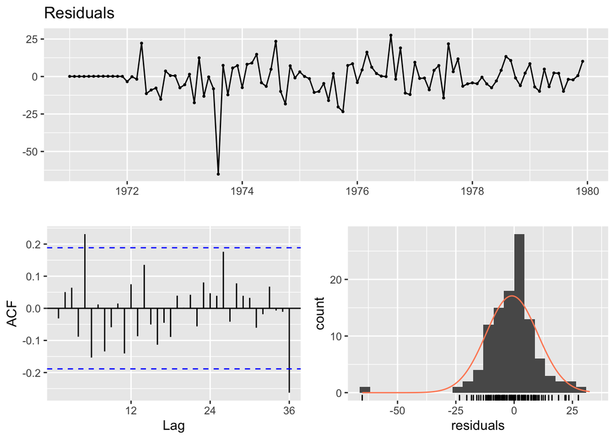

```r
residual <-window(m1$residuals)
checkresiduals(residual)
```

```r
Box.test(residual, type =  "Ljung-Box", lag = 12)
```

```
##
##  Box-Ljung test
##
## data:  residual
## X-squared = 16.366, df = 12, p-value = 0.1751
```

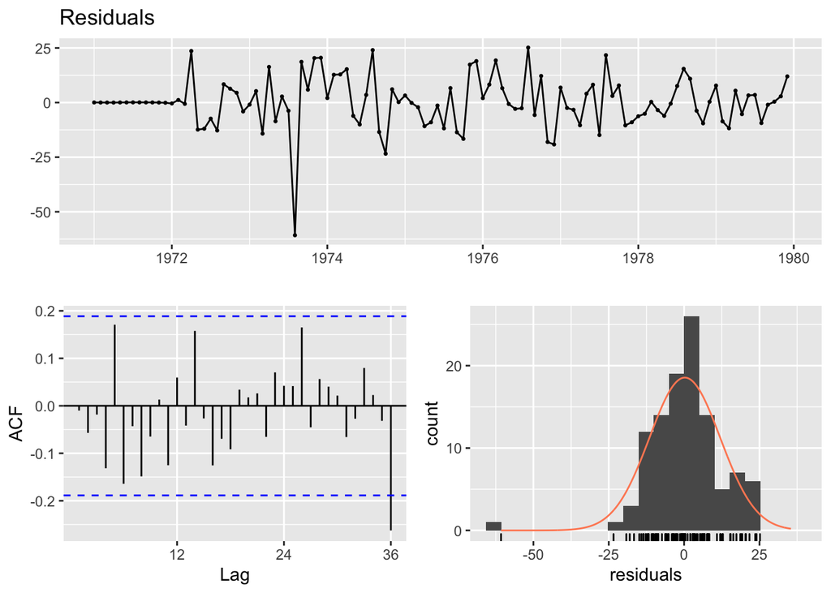

```r
residual2 <-window(m2$residuals)
checkresiduals(residual2)
```

```r
Box.test(residual2, type =  "Ljung-Box", lag = 12)
```

```
##
##  Box-Ljung test
##
## data:  residual2
## X-squared = 14.617, df = 12, p-value = 0.2631
```

(5 points) Question 6: Use both models from part 4 and the h-period argument in the forecast() function to forecast each month of 1980 (i.e., Jan, Feb, …, Dec.) Plot the test dataset and forecasted values.

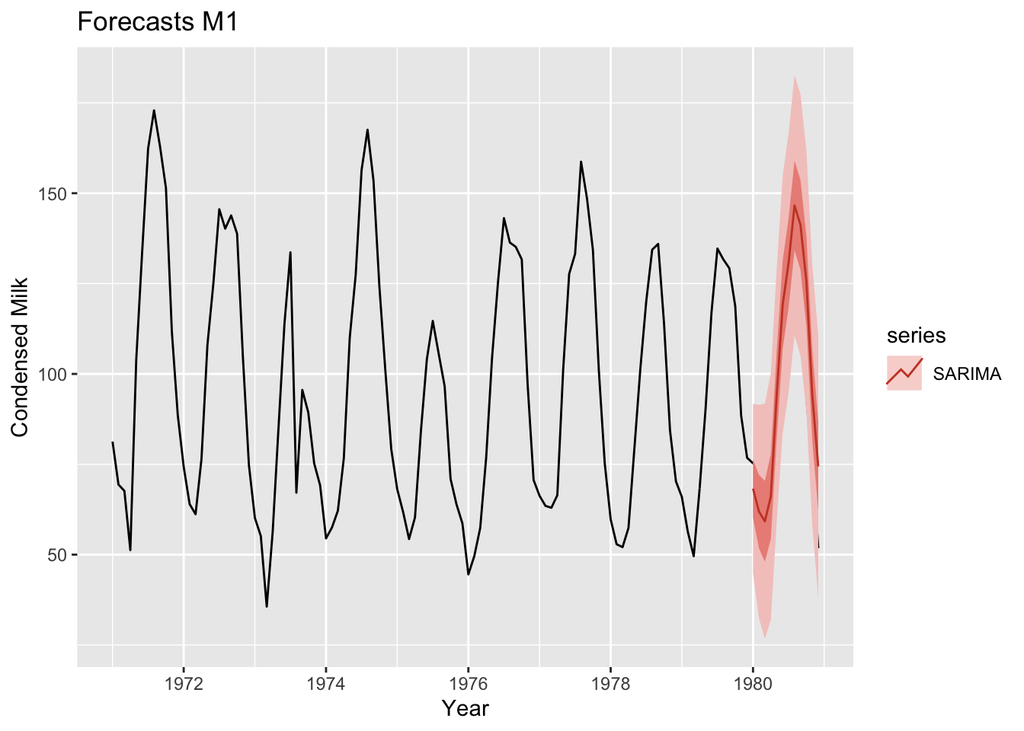

```r
library(ggplot2)
h = 12
m1_forecast <-forecast(m1, h, level=c(50, 95))

autoplot(condmilk) +
  autolayer(m1_forecast, series="SARIMA")+
  # autolayer(Model_Arima_forecast$mean, series="SARIMA")+
  ggtitle("Forecasts M1") +
  xlab("Year") + ylab("Condensed Milk")
```

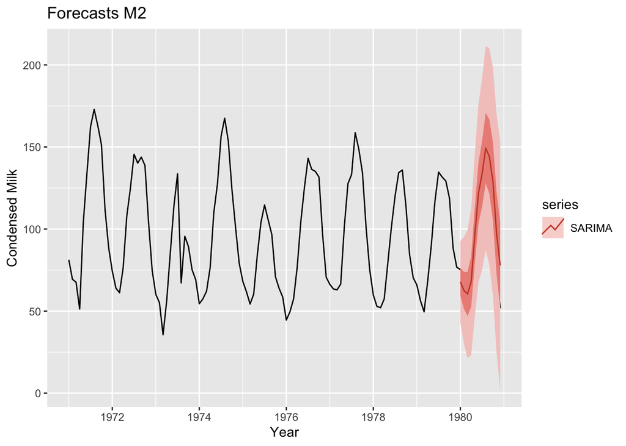

```r
library(ggplot2)
h = 12
m2_forecast <-forecast(m2, h, level=c(50, 95))

autoplot(condmilk) +
  autolayer(m2_forecast, series="SARIMA")+
  # autolayer(Model_Arima_forecast$mean, series="SARIMA")+
  ggtitle("Forecasts M2") +
  xlab("Year") + ylab("Condensed Milk")
```

(5 points) Question 7: Compare the forecast with the actual test data by calculating the Mean Absolute Percentage Error (MAPE) and Mean Squared Error (MSE). Which model is better to forecast the Manufacturer’s Stocks for each month of 1980 (i.e., Jan, Feb, …, Dec)?

```r
accuracy(m1_forecast, testdat)
```

```
##                      ME     RMSE      MAE       MPE     MAPE      MASE
## Training set -0.9574603 11.11569  7.32182 -1.720315  8.79587 0.3763464
## Test set     -3.8235083 17.59359 15.49988 -4.401343 18.42871 0.7967040
##                     ACF1 Theil's U
## Training set -0.03143506        NA
## Test set      0.80242534   1.23669
```

```r
m2_forecast <-forecast(m2, h, level=c(50, 95))
accuracy(m2_forecast, testdat)
```

```
##                      ME     RMSE       MAE        MPE      MAPE      MASE
## Training set  0.2319737 11.68546  8.137272  0.1015291  9.823743 0.4182612
## Test set     -6.0637439 18.97291 16.784780 -6.8863495 19.857210 0.8627489
##                      ACF1 Theil's U
## Training set -0.009998827        NA
## Test set      0.805802752  1.301681
```

```r
m1_mse = sum((m1_forecast$mean - testdat) ^2)
m2_mse = sum((m2_forecast$mean - testdat) ^2)
c(m1_mse,m2_mse)
```

```
## [1] 3714.414 4319.655
```